# Auswertung V4

Erik Marx

2024-09-02

Wir verfolgen zwei übergreifende Ziele:

1. Wir wollen die Eignung des Fragebogens als Testinstrument analysieren. Dazu verwenden wir einerseits Verfahren der klassischen Testtheorie (zum Beispiel Reliabilitätsanalyse) und Verfahren der Item-Response-Theory (IRT). Ziel ist es ein fundiertes Instrument zu erhalten, mit dem Konzeptwissen erhoben werden kann.
2. Wir wollen die Eignung des Fragebogens als Diagnoseinstrument untersuchen. Wir nutzen dafür hauptsächlich grafische Darstellungsarten, um die Verteilung von Antworten und Fehlvorstellungen zu visualsieren. Zusätzlich analysieren wir, inwiefern sich die Befragten Clustern lassen.

Entsprechend der Ziele ist der Bericht in zwei große Teile aufgeteilt. Zuvor wollen wir jedoch die vorliegenden Daten laden und bereinigen.

# Data Preperation

## Daten laden

```r
# Fragenkürzel und Glossar definieren
fragenkürzel_GE <- c("GE02", "GE04", "GE06", "GE08", "GE10", "GE12", "GE14")
fragenkürzel_TG <- c("TG02", "TG04", "TG06","TG07", "TG09", "TG11", "TG13", "TG15")
fragenkürzel_gesamt <- c(fragenkürzel_GE,fragenkürzel_TG)
fragenkürzel_mc <- c("GE02", "GE04", "GE08", "GE10", "GE12", "GE14", "TG02", "TG04", "TG09", "TG11", "TG13", "TG15")
fragenkürzel_sc <- c("GE06","TG06","TG07")
itemkürzel_mc_korrekt <- c("GE02_02", "GE04_02", "GE08_02", "GE10_04", "GE12_02", "GE14_01", "TG02_02", "TG04_02", "TG09_03", "TG11_03", "TG13_02", "TG15_03")


# Daten laden
filename <- "2024-10-15.csv"
data <- read.csv(paste0(directory,filename), fileEncoding='UTF-16') %>%
    rowwise() %>%
  filter(mean(c_across(c(TIME003:TIME009,TIME011:TIME017)),na.rm = TRUE)>=20) %>% #Schüler die zu schnell waren ausfiltern
  ungroup() %>%
  mutate(across(starts_with("GE14_"), ~ ifelse(CASE >= 323 & CASE <= 408, NA, .))) %>% #In einer Gruppe war die Frage GE14 anders, daher werden hier alle Antworten zu NA gesetzt
  mutate(across(starts_with(fragenkürzel_mc), ~ ifelse(. == 2, 0, .))) %>% #Daten umcodieren. 0 = falsch, 1 = wahr
  select(order(colnames(.)))

fragenkürzel_itemnames <- data %>%
  select(matches(paste(fragenkürzel_gesamt, collapse = "|"))) %>%
  names(.)
fragenkürzel_itemnames_GE <-str_subset(fragenkürzel_itemnames, "GE")
fragenkürzel_itemnames_TG <-str_subset(fragenkürzel_itemnames, "TG")


data_vorwissen <- data %>%
  select(contains('VK'))



glossar_mc <- list(
  GE02 = c(0, 1, 0),
  GE04 = c(0, 1, 0,0,0),
  GE08 = c(0, 1, 0,0),
  GE10 = c(0, 0, 0,1,0),
  GE12 = c(0,1,0,0),
  GE14 = c(1,0,0,0),
  TG02 = c(0, 1, 0,0,0),
  TG04 = c(0,1,0,0),
  TG09 = c(0,0,1,0),
  TG11 = c(0, 0, 1,0,0),
  TG13 = c(0,1,0,0),
  TG15 = c(0,0,1,0)
)

glossar_sc <- list(
  GE06 = 3,  # Correct answer for GE06
  TG06 = 3,  # Correct answer for TG06
  TG07 = 3   # Correct answer for TG07
)
```

## Überblick

```r
data %>%
  slice_head(n= 2) %>%
  select(14:22) %>%
  kbl(caption = "Ausschnitt aus dem Datensatz") %>%
  kable_styling()
```

Ausschnitt aus dem Datensatz

| GE02_01 | GE02_02 | GE02_03 | GE03_01 | GE03_02 | GE04_01 | GE04_02 | GE04_03 | GE04_04 |
| --- | --- | --- | --- | --- | --- | --- | --- | --- |
| 1 | 0 | 1 | 7 | 5 | 1 | 0 | 0 | 0 |
| 1 | 0 | 1 | 7 | 6 | 1 | 1 | 0 | 1 |

Danach kommen immer zwei Spalten in denen das *Verständnis* der Frage und das *Vertrauen* in die Antwort abgegeben wurden. Die Werte können von 1 (sehr gering) bis 7 (sehr hoch) reichen.

*Fehlende Werte*

Es wurden nicht alle Fragebögen vollständig ausgefüllt. Teilweise wurden auch Antworten nicht gespeichert, so dass Daten fehlen. Diese sind alle als NA codiert. In unseren Auswertungsmethodiken nehmen wir darauf Rücksicht.

*Daten bereinigen*

- falsches Item bei Motivation
- Antwortzeiten
- Antwortoption GE14_03

# Scoring

Rückblick: es gibt verschiedene Möglichkeiten die Antworten zu scoren. Dies waren:

**Standardverfahren**

- Antworten werden Itemweise, also für jede Antwort betrachtet
- Für jede richtige Antwort gibt es einen Punkt. Für Falschantworten gibt es keine Punkte, aber auch keine Abzüge.
- Gesamtzahl der erreichten Punkte im Fragebogen ist damit normalverteilt (wenn Fähigkeiten der Befragten normalverteilt).

**Formula Scoring**

- Antworten werden Itemweise ausgewertet.
- Für jede richtige Antwort gibt es einen Punkt. Bei Falschantwort werden Punkte abgezogen, aber abhängig von der Anzahl der Antwortalternativen $m$ mit $-1/(m-1)$. Da immer nur zwei Optionen zur Verfügung stehen (“wahr” oder “falsch”) wird bei falscher Antwort ein Punkt abgezogen. Ausnahme bilden die drei Single-Choice Aufgaben, bei denen ein Malus von $-1/2$ gegeben wird

**Testlet-Scoring**

- Antworten werden Frageweise ausgewertet
- Es gibt einen Punkt pro Frage, wenn für die Frage alle Aussagen richtig beantwortet wurden.
- Minimiert Einfluss von Raten, dafür ist aber Zusammenhang zwischen erwarteten Ergebnis und Wissen nicht mehr linear. Ebenso sind Varianz und Standardabweichung besonders groß

```r
#Funktionen definieren für Standardverfahren
calculate_score_mc_standard <- function(question, glossar, data) {
  correct_answers <- glossar[[question]]
  num_options <- length(correct_answers)

  score_column <- paste0(question, "_Score_Standard")
  data[[score_column]] <- 0

  for (i in 1:num_options) {
    # Der Befehl sprintf("_%02d", i) formatiert die Zahl i als zweistellige Zahl mit führenden Nullen und fügt einen Unterstrich davor.
    # Beispiel: Wenn i = 1, ergibt sprintf("_%02d", 1) die Zeichenkette "_01".
    answer_column <- paste0(question, sprintf("_%02d", i))
    correct <- correct_answers[i]

    data[[score_column]] <- data[[score_column]] +
      ifelse(data[[answer_column]] == correct, 1, 0)
  }

  return(data)
}

calculate_score_sc_standard <- function(question, glossar, data) {
  correct_answer <- glossar[[question]]

  score_column <- paste0(question, "_Score_Standard")
  data[[score_column]] <- ifelse(data[[question]] == correct_answer, 1, 0)

  return(data)
}

#Funktionen definieren für Formulaverfahren
calculate_score_mc_formula <- function(question, glossar, data) {
  correct_answers <- glossar[[question]]
  num_options <- length(correct_answers)

  score_column <- paste0(question, "_Score_Formula")
  data[[score_column]] <- 0

  for (i in 1:num_options) {
    answer_column <- paste0(question, sprintf("_%02d", i))
    correct <- correct_answers[i]

    data[[score_column]] <- data[[score_column]] +
      ifelse(data[[answer_column]] == correct, 1, -1)
  }

  return(data)
}

calculate_score_sc_formula <- function(question, glossar, data) {
  correct_answer <- glossar[[question]]

  score_column <- paste0(question, "_Score_Formula")
  data[[score_column]] <- ifelse(data[[question]] == correct_answer, 1, -1/2)

  return(data)
}

#Funktionen definieren für Testletverfahren
calculate_score_mc_testlet <- function(question, glossar, data) {
  correct_answers <- glossar[[question]]
  num_options <- length(correct_answers)

  score_column <- paste0(question, "_Score_Testlet")
  score_column_standard <- paste0(question, "_Score_Standard")
  data[[score_column]] <- 0
  data[[score_column]] <- ifelse(data[[score_column_standard]]==num_options,1,0)

  return(data)
}


calculate_score_sc_testlet <- function(question, glossar, data) {
  correct_answers <- glossar[[question]]
  num_options <- length(correct_answers)

  score_column <- paste0(question, "_Score_Testlet")
  score_column_standard <- paste0(question, "_Score_Standard")
  data[[score_column]] <- 0
  data[[score_column]] <- ifelse(data[[score_column_standard]]==3, 1, 0)

  return(data)
}

question_scores <- data
#Scores berechnen
for (question in fragenkürzel_mc) {
    question_scores <- calculate_score_mc_standard(question, glossar_mc, question_scores)
    question_scores <- calculate_score_mc_formula(question, glossar_mc, question_scores)
    question_scores <- calculate_score_mc_testlet(question, glossar_mc, question_scores)
}

for (question in fragenkürzel_sc) {
    question_scores <- calculate_score_sc_standard(question, glossar_sc, question_scores)
    question_scores <- calculate_score_sc_formula(question, glossar_sc, question_scores)
    question_scores <- calculate_score_sc_testlet(question, glossar_sc, question_scores)
}

#Spalten wieder in richtige Reihenfolge bringen
question_scores <- question_scores %>%
  select(order(colnames(question_scores)))


#Gesamtscores berechnen
question_scores <- question_scores %>%
  select(contains('_Score')) %>%
  rowwise() %>%
  mutate(Score_Standard_Total=sum(c_across(ends_with('Score_Standard')))) %>%
  mutate(Score_Formula_Total=sum(c_across(ends_with('Score_Formula')))) %>%
  mutate(Score_Testlet_Total=sum(c_across(ends_with('Score_Testlet')))) %>%
  ungroup()

question_scores %>%
  mutate(Score_Formula_Total=round(Score_Formula_Total,2)) %>%
  select(Score_Standard_Total, Score_Formula_Total, Score_Testlet_Total)
```

```
## # A tibble: 337 × 3
##    Score_Standard_Total Score_Formula_Total Score_Testlet_Total
##                   <dbl>               <dbl>               <dbl>
##  1                   NA                NA                    NA
##  2                   32                10.5                   0
##  3                   27                 1.5                   1
##  4                   28                 3.5                   0
##  5                   23                -6.5                   0
##  6                   26                -0.5                   0
##  7                   28                 3                     0
##  8                   NA                NA                    NA
##  9                   NA                NA                    NA
## 10                   NA                NA                    NA
## # ℹ 327 more rows
```

```r
recode_for_rasch <- function(data, columns_mc, columns_sc, glossar_mc, glossar_sc){
  for (question in columns_mc) {
    correct_answers <- glossar_mc[[question]]
    num_options <- length(correct_answers)

    for (i in 1:num_options) {
      # Der Befehl sprintf("_%02d", i) formatiert die Zahl i als zweistellige Zahl mit führenden Nullen und fügt einen Unterstrich davor.
      # Beispiel: Wenn i = 1, ergibt sprintf("_%02d", 1) die Zeichenkette "_01".
      answer_column <- paste0(question, sprintf("_%02d", i))
      correct <- correct_answers[i]

      data[[answer_column]] <- ifelse(is.na(data[[answer_column]]), NA,
                                ifelse(data[[answer_column]] == correct, 1, 0))
    }
  }

  for (question in columns_sc) {
    correct_answer <- glossar_sc[[question]]

    data[[question]] <- ifelse(is.na(data[[question]]), NA,
                        ifelse(data[[question]] == correct_answer, 1, 0))

  }

  return(data)
}

data_items <- select(data,contains(fragenkürzel_gesamt))
data_score_raw <- recode_for_rasch(data_items, fragenkürzel_mc, fragenkürzel_sc, glossar_mc, glossar_sc)
data_score_standard <- question_scores %>%
  select(contains("Standard")) %>%
  rename_with(~str_remove(., '_Score_Standard')) %>%
  select(!Score_Standard_Total)

write.csv(data_score_raw, file=file.path('Daten','data_score_raw.csv'))
write.csv(data_items, file=file.path('Daten','data_items.csv'))
write.csv(data_score_standard, file=file.path('Daten','data_score_standard.csv'))
```

Wir wollen im nächsten Schritt erst einmal nur den Standard-Score betrachten (Begründung siehe nächsten Abschnitt). Schauen wir uns einmal die Verteilung der Scores an.

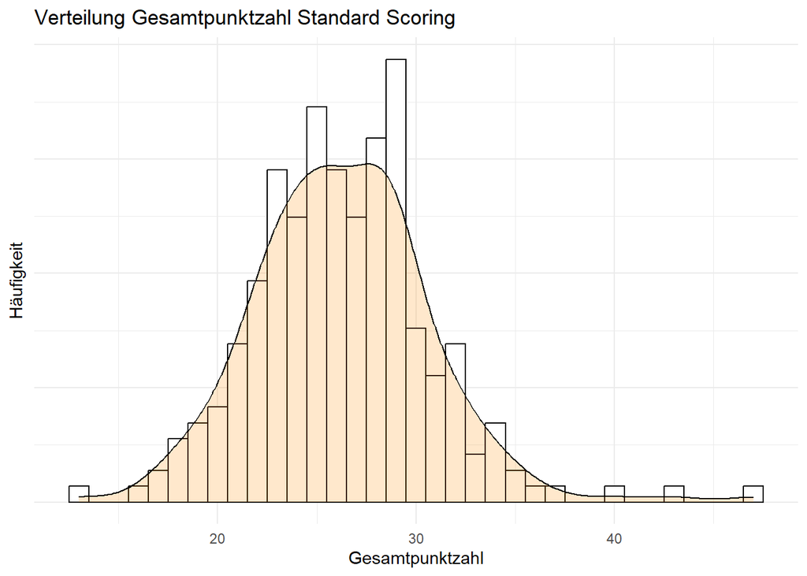

```r
question_scores %>%
  ggplot(aes(x=Score_Standard_Total,)) +
    geom_histogram(aes(y=after_stat(density)), colour = "black", fill="white", binwidth = 1) +
    geom_density(alpha=.2, fill="darkorange") +
    labs(
      title = "Verteilung Gesamtpunktzahl Standard Scoring",
      x = "Gesamtpunktzahl",
      y = "Häufigkeit") +
    theme_minimal() +
    theme(
      axis.text.y = element_blank()
    )
```

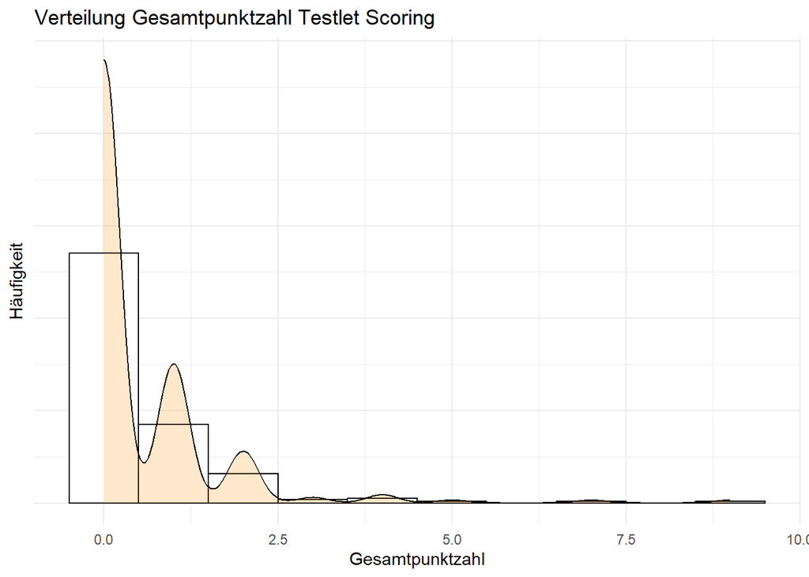

```r
question_scores %>%
  ggplot(aes(x=Score_Testlet_Total,)) +
    geom_histogram(aes(y=after_stat(density)), colour = "black", fill="white", binwidth = 1) +
    geom_density(alpha=.2, fill="darkorange") +
    labs(
      title = "Verteilung Gesamtpunktzahl Testlet Scoring",
      x = "Gesamtpunktzahl",
      y = "Häufigkeit") +
    theme_minimal() +
    theme(
      axis.text.y = element_blank()
    )
```

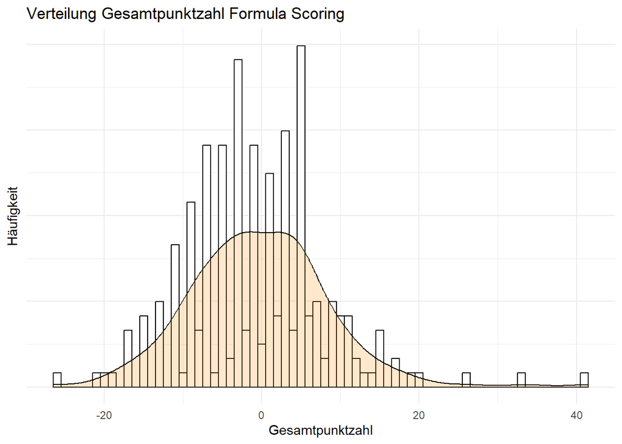

```r
question_scores %>%
  ggplot(aes(x=Score_Formula_Total,)) +
    geom_histogram(aes(y=after_stat(density)), colour = "black", fill="white", binwidth = 1) +
    geom_density(alpha=.2, fill="darkorange") +
    labs(
      title = "Verteilung Gesamtpunktzahl Formula Scoring",
      x = "Gesamtpunktzahl",
      y = "Häufigkeit") +
    theme_minimal() +
    theme(
      axis.text.y = element_blank()
    )
```

Wenn wir uns die Verteilung der Punktzahlen anschauen, bildet eigentlich nur das Standardscoring eine schöne Verteilung, weswegen wir uns im Folgenden nur das anschauen wollen. Maximalpunktzahl sind 54 Punkte.

# Fragbogen als Testinstrument

## ITR

Warum nutzen wir zur Auswertung unseres Tests die Item-Response-Theory (IRT) und nicht Verfahren der klassischen Testtheorie (KTT)? Es seien kurz eine Auswahl der Annahmen der KTT zusammengefasst (Becker, 2004): - Der beobachtete Wert einer Person ist die wahre Wert der Person plus einem Messfehler - alle diese Werte sind normalverteilt - Der Fehler ist unabhängig vom wahren Wert der Person und anderen Tests

Daneben gibt es noch weitere Axiome. Die KTT hat jedoch auch einige Schwächen. Hier wieder Auszüge: - Die Axiome sind nicht empirisch überprüfbar (ich kann nicht testen, ob meine Messergebnisse normalverteilt sind) - Dass der Messfehler über alle Merkmalsausprägungen gleich groß ist, ist empirisch nicht begründet bzw. sehr unwahrscheinlich - Generell können Aussagen zum Beispiel zur Reliabilität nur in Verbindung zum Gesamttestergebnis gemacht werden (Berechnung von einem Cronbachs Alpha) - Der größte Nachteil ist wohl, dass die berechenbaren Item-, Test- und Personenstatistiken stichprobenabhängig sind

IRT begegnet diesen Annahmen und Nachteilen und bietet einige Vorteile, darin begründet, dass Tests Itemweise ausgewertet werden und nicht in Abhängigkeit zum Gesamttestergebnis. Zentrale Idee: eine Person hat für jede Frage eine bestimmte Chance diese richtig zu beantworten, basierend auf den Eigenschaften der Person und des Items (Edwards & Alcock, 2010). Da sowohl Personen, als auch Itemparameter auf einer Skala positioniert werden, aber unabhängig voneinaner geschätzt werden können, sind diese Stichprobenunabhängig. Auch die Annahme, dass der Standardmessfehler konstant ist, wird verworfen. Stattdessen können Messfehler individuell abhängig von der latenten Merkmalsausprägung und dem Item bestimmt werden. Es kann damit viel genauer bestimmt werden, wann ein Test genau misst.

- Scoringdiskusion
- Rasch Partial credit model (PCM)

Voraussetzungen für IRT sind Unidemnsionalität und lokale Unabhängigkeit.

### Voraussetzung: Unidimensionalität

Die nachfolgenden IRT Methoden setzen vorauss, dass nur eine latente Variable der Beantwortung der Fragen zugrunde liegt. Konkret bedeutet dies, dass es ein “ML-Wissen” gibt, mit dem die Fragen beantwortet werden. Eine zweite Möglichkeit besteht natürlich darin, dass es ein “Gesichtserkennungs-ML-Wissen” und ein “ChatGPT-ML-Wissen” gibt. Wir wollen daher zuerst ermitteln, ob unser Test Unidimensional ist.

Wir testen auf Undidimensionalität, indem wir mit einer konfirmatorischen Faktor Analyse (CFA) untersuchen, ob unserer Fragebogen eher ein oder zwei Faktoren besitzt.

- (Hornberger et al., 2023) haben die Unidimensionalität in ihrer Studie mittels konfirmatorischer Faktoranalyse nachgewiesen.

https://pure.rug.nl/ws/portalfiles/portal/111699318/9781118489772.ch15.pdf führen KFA nicht an, dafür aber zwei andere Verfahren: - automated item selection algorithm (AISP) nach Mokken - nonparametric DETECT approach

Wir beginnen mit der KFA mit dem Package lavaan. Alle Infos aus: https://stats.oarc.ucla.edu/r/seminars/rcfa/#s2 Wir verwenden den Parameter `estimator='WLSMV'`. Das heißt einfach nur, dass wir den Estimator DWLS verwenden, der speziell für ordinale Daten entwickelt wurde, und einen mean- und variance-adjusted (MV) chi-squared test Statistik anhängen. Das beides zusammen wird mit `WLSMV` angegeben. Außerdem geben wir mit `ordered()` an, dass die angegeben Spalten ordinal sind.

```r
# cfa_data_raw <- data %>%
#   select(matches(paste(fragenkürzel_gesamt, collapse = "|")))

#fehlend: GE04_03, GE12_01, GE12_04, GE14_02, "TG02_03", "TG13_01", "TG13_04", "TG15_02"
#doppelt: "GE08_04", "TG09_04"
# c_mc_pb = c("GE02_01","GE04_01", "GE08_03", "GE10_03", "GE14_04", "TG02_01", "TG04_01", "TG09_02", "TG11_01")
# c_mc_st = c("GE02_03", "GE10_01", "GE10_02", "TG04_03", "TG04_04", "TG11_02", "TG11_04", "TG15_04")
# c_mc_ut = c("GE04_04", "GE14_03", "TG02_05", "TG09_04", "GE08_04", "TG15_01")
# c_mc_ac = c("GE04_05", "TG02_04")
# c_mc_cl = c("GE08_01", "GE08_04", "GE10_05", "GE12_03", "TG09_01", "TG09_04", "TG11_05", "TG13_03")
#
# cfa_itemnames_misc_pb <- paste('\n',c_mc_pb[1],'~~',paste(c_mc_pb[-1], collapse = '+'))
# cfa_itemnames_misc_st <- paste('\n',c_mc_st[1],'~~',paste(c_mc_st[-1], collapse = '+'))
# cfa_itemnames_misc_ut <- paste('\n',c_mc_ut[1],'~~',paste(c_mc_ut[-1], collapse = '+'))
# cfa_itemnames_misc_ac <- paste('\n',c_mc_ac[1],'~~',paste(c_mc_ac[-1], collapse = '+'))
# cfa_itemnames_misc_cl <- paste('\n',c_mc_cl[1],'~~',paste(c_mc_cl[-1], collapse = '+'))

#cfa1f  <- paste('f  =~',cfa_itemnames_raw,cfa_itemnames_misc_pb,cfa_itemnames_misc_st,cfa_itemnames_misc_ut,cfa_itemnames_misc_ac,cfa_itemnames_misc_cl)

cfa_itemnames <- paste(fragenkürzel_itemnames, collapse = "+")
cfa1f_items  <- paste('f  =~',cfa_itemnames)



onefacmodel_items <- cfa(cfa1f_items, data=data_score_raw, estimator="WLSMV", missing="listwise", std.lv = TRUE, auto.fix.single = TRUE, ordered = fragenkürzel_itemnames)

    # meanstructure   = FALSE,
    # se              = "standard",
    # auto.var        = TRUE,
    # auto.cov.lv.x   = TRUE,
    # auto.th         = TRUE,
    # auto.delta      = TRUE,
    # auto.cov.y      = TRUE



summary(onefacmodel_items, fit.measures=TRUE, estimates = FALSE)
```

```
## lavaan 0.6-18 ended normally after 21 iterations
##
##   Estimator                                       DWLS
##   Optimization method                           NLMINB
##   Number of model parameters                       108
##
##                                                   Used       Total
##   Number of observations                           241         337
##
## Model Test User Model:
##                                               Standard      Scaled
##   Test Statistic                              3381.311    2197.093
##   Degrees of freedom                              1377        1377
##   P-value (Chi-square)                           0.000       0.000
##   Scaling correction factor                                  2.666
##   Shift parameter                                          928.627
##     simple second-order correction
##
## Model Test Baseline Model:
##
##   Test statistic                              6457.864    3016.159
##   Degrees of freedom                              1431        1431
##   P-value                                        0.000       0.000
##   Scaling correction factor                                  3.171
##
## User Model versus Baseline Model:
##
##   Comparative Fit Index (CFI)                    0.601       0.483
##   Tucker-Lewis Index (TLI)                       0.586       0.462
##
##   Robust Comparative Fit Index (CFI)                            NA
##   Robust Tucker-Lewis Index (TLI)                               NA
##
## Root Mean Square Error of Approximation:
##
##   RMSEA                                          0.078       0.050
##   90 Percent confidence interval - lower         0.075       0.046
##   90 Percent confidence interval - upper         0.081       0.054
##   P-value H_0: RMSEA <= 0.050                    0.000       0.527
##   P-value H_0: RMSEA >= 0.080                    0.148       0.000
##
##   Robust RMSEA                                                  NA
##   90 Percent confidence interval - lower                        NA
##   90 Percent confidence interval - upper                        NA
##   P-value H_0: Robust RMSEA <= 0.050                            NA
##   P-value H_0: Robust RMSEA >= 0.080                            NA
##
## Standardized Root Mean Square Residual:
##
##   SRMR                                           0.162       0.162
```

Comparative Fit Index (CFI) 0.601 Tucker-Lewis Index (TLI) 0.586

2. Lokale Abhängigkeiten überprüfen (https://chatgpt.com/c/66f58538-55c0-8007-b492-a79be9e06ad0)

Du kannst die Modifikationsindizes in lavaan prüfen, um herauszufinden, ob die Problem-Items signifikante Korrelationen der Residuen aufweisen. Ein hoher Modifikationsindex zwischen zwei Items bedeutet, dass die Modellanpassung verbessert werden könnte, wenn du ihre Residuen korrelieren lässt.

```r
modindices(onefacmodel_items, sort = TRUE, minimum.value = 10)
```

```
## # A tibble: 73 × 8
##    lhs     op    rhs        mi    epc sepc.lv sepc.all sepc.nox
##    <chr>   <chr> <chr>   <dbl>  <dbl>   <dbl>    <dbl>    <dbl>
##  1 TG02_02 ~~    TG02_03 109.  -0.713  -0.713   -0.714   -0.714
##  2 GE04_02 ~~    GE14_01  41.4 -0.521  -0.521   -0.567   -0.567
##  3 GE10_02 ~~    GE14_01  40.1  0.537   0.537    0.574    0.574
##  4 TG06    ~~    TG07     37.9 -0.547  -0.547   -0.547   -0.547
##  5 TG13_02 ~~    TG13_04  34.7 -0.545  -0.545   -0.591   -0.591
##  6 TG09_04 ~~    TG15_01  32.9 -0.433  -0.433   -0.601   -0.601
##  7 TG09_01 ~~    TG09_02  28.8  0.387   0.387    0.748    0.748
##  8 GE12_02 ~~    GE12_04  26.8 -0.549  -0.549   -0.616   -0.616
##  9 GE12_02 ~~    GE12_03  25.9 -0.477  -0.477   -0.677   -0.677
## 10 TG11_02 ~~    TG15_04  25.5 -0.447  -0.447   -0.520   -0.520
## # ℹ 63 more rows
```

Das lavaan package gibt direkt aus, wie gut das Einfaktormodel auf den Daten fittet. Dazu werden die Metriken Chi-square, CFI, TLI und RMSEA verwendet. Chi-Square wird abgelehnt (schlecht). Es ist aber gut dokumentiert, dass chi-square oft viel zu sensitiv ist, vor allem bei steigender Sample size. Daher sollten die anderen Testmetriken betrachtet werden. CFI und TLI sind inkrementale fit indexe, das heißt sie vergleichen das gefittete Model mit einem baseline model, bei dem es keine Abhängigkeit zwischen den Items gibt. Der Index geht von 0-1, wobei 0.9-1 gewünscht sind. Unser Modell fittet eher schlecht.

RMSEA ist ein absoluter fit index, hier wird das Modell gegen die tatsächlichen Daten verglichen. Für RMSEA gilt: $\leq 0.05$ gut, $0.5 \leq x \leq 0.8$ mittel und alles darüber schlecht. Demnach fittet unser Einfaktormodel also nur mäßig. Nach Hornberger sollte $SRMR <0.1$ sein, was bei uns auch nicht der Fall ist (nachprüfen). Hornberger führen auch auch, dass $\chi^2/df < 2–3$ sein sollte. Dies ist hier knapp der Fall. Gibbons & Cai: „Very roughly, a chi-square value is significant if it is at least twice as large as its degrees of freedom.“ -> Würde eigentlich für $\chi^2/df > 2–3$ sprechen oder habe ich einen Denkfehler?

Was heißt das nun? Das Einfaktormodel kann die Struktur unserer Daten nicht wirklich erklären. Entweder gibt es also mehr als eine Dimension oder das Model ist nicht gut spezifiziert (weil es zum Beispiel schlechte Items gibt). Gleichzeitig hat unser Model relativ kleine Fehler und Konfidenzintervalle. Das muss aber nicht heißen, dass es das “beste” Model ist. Wir können nun andere Modelle annehmen, unsere Daten mittel explorativer Faktoranalyse auf Faktoren untersuchen oder schauen, welche Items schlecht auf unseren Faktor laden und diese beispielsweise entfernen.

Insgesamt ist fraglich ob wir tatsächlich nur einen Faktor in unseren Daten haben. Wir sollten daher auch ein zwei Faktor Modell untersuchen.

```r
cfa_itemnames_GE <- paste(fragenkürzel_itemnames_GE, collapse = "+")
cfa_itemnames_TG <- paste(fragenkürzel_itemnames_TG, collapse = "+")

cfa2f_items  <- paste('f1  =~',cfa_itemnames_GE, '\nf2 =~', cfa_itemnames_TG)
twofacmodel_raw <- cfa(cfa2f_items, data=data_score_raw, ordered = names(data_items), estimator="WLSMV", missing="listwise", std.lv = TRUE, auto.fix.single = TRUE)
summary(twofacmodel_raw, fit.measures=TRUE, estimates = FALSE)
```

```
## lavaan 0.6-18 ended normally after 23 iterations
##
##   Estimator                                       DWLS
##   Optimization method                           NLMINB
##   Number of model parameters                       109
##
##                                                   Used       Total
##   Number of observations                           241         337
##
## Model Test User Model:
##                                               Standard      Scaled
##   Test Statistic                              2952.623    2020.603
##   Degrees of freedom                              1376        1376
##   P-value (Chi-square)                           0.000       0.000
##   Scaling correction factor                                  2.702
##   Shift parameter                                          927.721
##     simple second-order correction
##
## Model Test Baseline Model:
##
##   Test statistic                              6457.864    3016.159
##   Degrees of freedom                              1431        1431
##   P-value                                        0.000       0.000
##   Scaling correction factor                                  3.171
##
## User Model versus Baseline Model:
##
##   Comparative Fit Index (CFI)                    0.686       0.593
##   Tucker-Lewis Index (TLI)                       0.674       0.577
##
##   Robust Comparative Fit Index (CFI)                            NA
##   Robust Tucker-Lewis Index (TLI)                               NA
##
## Root Mean Square Error of Approximation:
##
##   RMSEA                                          0.069       0.044
##   90 Percent confidence interval - lower         0.066       0.040
##   90 Percent confidence interval - upper         0.073       0.048
##   P-value H_0: RMSEA <= 0.050                    0.000       0.991
##   P-value H_0: RMSEA >= 0.080                    0.000       0.000
##
##   Robust RMSEA                                                  NA
##   90 Percent confidence interval - lower                        NA
##   90 Percent confidence interval - upper                        NA
##   P-value H_0: Robust RMSEA <= 0.050                            NA
##   P-value H_0: Robust RMSEA >= 0.080                            NA
##
## Standardized Root Mean Square Residual:
##
##   SRMR                                           0.153       0.153
```

Insgesamt muss festgehalten werden, dass die CFA für die individuellen Statements gemischte Ergebnisse liefert. An dieser Stelle kann angemerkt werden, dass uns eventuell einfach die Datenmenge fehlt. Als Faustregel gilt pro Item ~ 10 Befragte. Da wir 54 items haben, bräuchten wir mindestens 540 Befragte, um ein aussagekräftigtes n zu haben.

**Standard Scoring**

Betrachten wir nun die KFA für das Standard Scoring. Da wir jeweils zwei Fragen zum gleichen Konzept haben (jeweils für GE und TG), ist zu erwarten, dass diese spezifisch miteinander korrelieren, unabhängig von dem Faktor “ML-Wissen” (Ich erkenne beim zweiten Mal die Frage wieder und kreuze ähnlich an). Um dies in unserem Modell zu berücksichtigen, korrelieren wir die Covarianzen der zueinandergehörigen Fragen miteinander (zum Beispiel `GE06 ~~ TG06`).

```r
cfa_itemnames_standard <- paste(fragenkürzel_gesamt, collapse = "+")

cfa1f_standard  <- paste('f  =~',cfa_itemnames_standard,'
                         GE02 ~~ TG04
                         GE04 ~~ TG02
                         GE06 ~~ TG06
                         GE06 ~~ TG07
                         TG06 ~~ TG07
                         GE08 ~~ TG09
                         GE10 ~~ TG11
                         GE12 ~~ TG13
                         GE14 ~~ TG15')
onefacmodel_standard <- cfa(cfa1f_standard, data=data_score_standard, ordered = fragenkürzel_gesamt, estimator="WLSMV")
summary(onefacmodel_standard, fit.measures=TRUE, estimates = FALSE)
```

```
## lavaan 0.6-18 ended normally after 48 iterations
##
##   Estimator                                       DWLS
##   Optimization method                           NLMINB
##   Number of model parameters                        77
##
##                                                   Used       Total
##   Number of observations                           241         337
##
## Model Test User Model:
##                                               Standard      Scaled
##   Test Statistic                               115.233     118.115
##   Degrees of freedom                                81          81
##   P-value (Chi-square)                           0.007       0.004
##   Scaling correction factor                                  1.148
##   Shift parameter                                           17.771
##     simple second-order correction
##
## Model Test Baseline Model:
##
##   Test statistic                               377.774     300.286
##   Degrees of freedom                               105         105
##   P-value                                        0.000       0.000
##   Scaling correction factor                                  1.397
##
## User Model versus Baseline Model:
##
##   Comparative Fit Index (CFI)                    0.875       0.810
##   Tucker-Lewis Index (TLI)                       0.837       0.754
##
##   Robust Comparative Fit Index (CFI)                         0.845
##   Robust Tucker-Lewis Index (TLI)                            0.799
##
## Root Mean Square Error of Approximation:
##
##   RMSEA                                          0.042       0.044
##   90 Percent confidence interval - lower         0.022       0.025
##   90 Percent confidence interval - upper         0.059       0.060
##   P-value H_0: RMSEA <= 0.050                    0.771       0.719
##   P-value H_0: RMSEA >= 0.080                    0.000       0.000
##
##   Robust RMSEA                                               0.051
##   90 Percent confidence interval - lower                     0.022
##   90 Percent confidence interval - upper                     0.074
##   P-value H_0: Robust RMSEA <= 0.050                         0.444
##   P-value H_0: Robust RMSEA >= 0.080                         0.018
##
## Standardized Root Mean Square Residual:
##
##   SRMR                                           0.070       0.070
```

Die inkrementalen Index CFI und TLI sind hier besser. Dies deckt sich mit den Empfehlungen aus der Literatur. So wird bei einem non-fit von dichotoumen Variablen vorgeschlagen, die Daten polytom zusammenzufassen, da dies meist einen besseren fit erzeugt. Auch RMSEA und SRMSR sind sehr gut. Wir können also mit diesem Modell weiterarbeiten. Schauen wir uns einmal an, welche Items noch schlecht auf den Faktor laden.

```r
#modindices(onefacmodel_standard, sort = TRUE, minimum.value = 10)
# params_standard <- parameterEstimates(onefacmodel_standard) %>%
#   select(rhs,est) %>%
#   kbl(caption = "Faktorladungen der Items") %>%
#   kable_classic(full_width = F, html_font = "Cambria")
#
# summary(onefacmodel_standard,header = FALSE, estimates = TRUE)
```

```r
cfa_itemnames_standard_GE <- paste(fragenkürzel_GE, collapse = "+")
cfa_itemnames_standard_TG <- paste(fragenkürzel_TG, collapse = "+")

#cfa2f <- paste('f1  =~',cfa_itemnames_standard_GE, '\nf2 =~', cfa_itemnames_standard_TG)
cfa2f <- 'f1 =~ GE02+GE04+GE06+GE08+GE10+GE12+GE14
          f2 =~ TG02+TG04+TG06+TG07+TG09+TG11+TG13+TG15
          GE02 ~~ TG04
          GE04 ~~ TG02
          GE06 ~~ TG06
          GE06 ~~ TG07
          TG06 ~~ TG07
          GE08 ~~ TG09
          GE10 ~~ TG11
          GE12 ~~ TG13
          GE14 ~~ TG15'
twofacmodel_standard <- cfa(cfa2f, data=data_score_standard, ordered = names(data_score_standard), estimator="WLSMV")
summary(twofacmodel_standard, header=FALSE, fit.measures=TRUE, estimates = FALSE)
```

```
##
## Model Test Baseline Model:
##
##   Test statistic                               377.774     300.286
##   Degrees of freedom                               105         105
##   P-value                                        0.000       0.000
##   Scaling correction factor                                  1.397
##
## User Model versus Baseline Model:
##
##   Comparative Fit Index (CFI)                    0.898       0.839
##   Tucker-Lewis Index (TLI)                       0.866       0.789
##
##   Robust Comparative Fit Index (CFI)                         0.884
##   Robust Tucker-Lewis Index (TLI)                            0.848
##
## Root Mean Square Error of Approximation:
##
##   RMSEA                                          0.038       0.040
##   90 Percent confidence interval - lower         0.016       0.020
##   90 Percent confidence interval - upper         0.055       0.057
##   P-value H_0: RMSEA <= 0.050                    0.861       0.810
##   P-value H_0: RMSEA >= 0.080                    0.000       0.000
##
##   Robust RMSEA                                               0.045
##   90 Percent confidence interval - lower                     0.000
##   90 Percent confidence interval - upper                     0.069
##   P-value H_0: Robust RMSEA <= 0.050                         0.613
##   P-value H_0: Robust RMSEA >= 0.080                         0.006
##
## Standardized Root Mean Square Residual:
##
##   SRMR                                           0.069       0.069
```

```r
summary(twofacmodel_standard, header=FALSE, fit.measures=FALSE, estimates = TRUE)
```

```
##
## Parameter Estimates:
##
##   Parameterization                               Delta
##   Standard errors                           Robust.sem
##   Information                                 Expected
##   Information saturated (h1) model        Unstructured
##
## Latent Variables:
##                    Estimate  Std.Err  z-value  P(>|z|)
##   f1 =~
##     GE02              1.000
##     GE04              1.148    0.453    2.532    0.011
##     GE06             -0.751    0.487   -1.542    0.123
##     GE08              0.713    0.358    1.990    0.047
##     GE10              0.808    0.380    2.128    0.033
##     GE12              1.189    0.481    2.473    0.013
##     GE14              0.786    0.387    2.028    0.043
##   f2 =~
##     TG02              1.000
##     TG04              2.882    1.154    2.498    0.013
##     TG06              0.627    0.671    0.935    0.350
##     TG07             -0.242    0.531   -0.457    0.648
##     TG09              0.295    0.406    0.726    0.468
##     TG11              3.093    1.264    2.448    0.014
##     TG13              0.062    0.394    0.158    0.874
##     TG15              1.416    0.627    2.258    0.024
##
## Covariances:
##                    Estimate  Std.Err  z-value  P(>|z|)
##  .GE02 ~~
##    .TG04              0.121    0.072    1.684    0.092
##  .GE04 ~~
##    .TG02              0.184    0.066    2.793    0.005
##  .GE06 ~~
##    .TG06              0.428    0.109    3.936    0.000
##    .TG07              0.385    0.109    3.520    0.000
##  .TG06 ~~
##    .TG07              0.556    0.088    6.346    0.000
##  .GE08 ~~
```

[output cut: 70 more lines]

```
##    .GE06              0.942
##    .GE08              0.948
##    .GE10              0.933
##    .GE12              0.856
##    .GE14              0.937
##    .TG02              0.957
##    .TG04              0.647
##    .TG06              0.983
##    .TG07              0.997
##    .TG09              0.996
##    .TG11              0.593
##    .TG13              1.000
##    .TG15              0.915
##     f1                0.102    0.061    1.684    0.092
##     f2                0.043    0.032    1.335    0.182
```

Wichtig sind hier die Werte unter Latent Variables

Wenn wir die Faktorladungen betrachten, fällt uns auf, dass vor allem die Single-Choice Fragen schlecht auf den Faktor laden. Da diese ein anderes Fragenformat haben, kann es sein, dass sie durch unsere Modellspezifkikation nicht richtig abgefangen werden.

## PCM

```r
# Daten müssen in mehr als einer Spalte Werte enthalten.
# Da später beim LR-Test Spalten ausgeschlossen werden, wird der Wert hier höher gesetzt, damit es dann immernoch funktioniert
pcm_data <- data_score_standard %>%
  filter(rowSums(!is.na(.)) > 1)

write.csv(pcm_data, file=file.path('Daten','pcm_data.csv'))


pcm <- PCM(pcm_data)
summary(pcm)
```

```
##
## Results of PCM estimation:
##
## Call:  PCM(X = pcm_data)
##
## Conditional log-likelihood: -4657.592
## Number of iterations: 277
## Number of parameters: 52
##
## Item (Category) Difficulty Parameters (eta): with 0.95 CI:
##         Estimate Std. Error lower CI upper CI
## GE02.c2    0.868      0.185    0.506    1.231
## GE02.c3    2.149      0.268    1.624    2.674
## GE04.c1   -1.502      0.352   -2.192   -0.811
## GE04.c2   -2.176      0.342   -2.846   -1.507
## GE04.c3   -1.887      0.355   -2.582   -1.191
## GE04.c4   -1.161      0.379   -1.903   -0.418
## GE04.c5    1.639      0.565    0.532    2.747
## GE06.c1    1.747      0.151    1.451    2.043
## GE08.c1   -1.199      0.348   -1.881   -0.516
## GE08.c2   -2.359      0.328   -3.001   -1.716
## GE08.c3   -1.949      0.343   -2.622   -1.276
## GE08.c4    0.409      0.432   -0.438    1.256
## GE10.c1   -1.568      0.326   -2.207   -0.929
## GE10.c2   -2.207      0.320   -2.834   -1.580
## GE10.c3   -1.658      0.338   -2.320   -0.995
## GE10.c4    0.190      0.405   -0.603    0.983
## GE10.c5    9.441      6.012   -2.342   21.224
## GE12.c1   -0.917      0.384   -1.669   -0.165
## GE12.c2   -1.695      0.358   -2.397   -0.993
## GE12.c3   -2.589      0.356   -3.288   -1.890
## GE12.c4    0.022      0.428   -0.818    0.862
## GE14.c1   -0.272      0.164   -0.593    0.050
## GE14.c2    0.179      0.189   -0.191    0.548
## GE14.c3    3.199      0.429    2.359    4.040
## TG02.c1   -0.134      0.243   -0.609    0.342
## TG02.c2   -0.918      0.208   -1.325   -0.511
## TG02.c3   -1.096      0.212   -1.512   -0.681
## TG02.c4   -0.291      0.227   -0.735    0.153
## TG02.c5    2.370      0.426    1.536    3.204
```

[output cut: 64 more lines]

```
## beta TG09.c3   -0.522      0.205   -0.923   -0.121
## beta TG09.c4   -1.983      0.325   -2.620   -1.346
## beta TG11.c1    0.790      0.209    0.380    1.200
## beta TG11.c2    1.196      0.205    0.794    1.598
## beta TG11.c3    0.761      0.226    0.318    1.204
## beta TG11.c4   -1.031      0.301   -1.621   -0.440
## beta TG11.c5   -3.582      0.654   -4.863   -2.300
## beta TG13.c1    1.225      0.223    0.789    1.661
## beta TG13.c2    1.182      0.231    0.730    1.635
## beta TG13.c3    1.228      0.243    0.751    1.704
## beta TG13.c4   -0.782      0.325   -1.420   -0.145
## beta TG15.c1    1.020      0.246    0.537    1.502
## beta TG15.c2    1.606      0.237    1.141    2.070
## beta TG15.c3    1.446      0.254    0.949    1.944
## beta TG15.c4   -1.277      0.283   -1.832   -0.722
```

- Item-Schwierigkeiten (Eta-Parameter)
- Item-Einfachheitsparameter (Beta-Parameter)
  - Estimate: Einfachheit diese Punktzahl zu erreichen. Je höher der Wert, desto einfacher
  - Std. Error: Unsicherheit des geschätzten Parameters
  - 95% CI (lower und upper): 95%-Konfidenzintervall

### Fitting

- Gedanken zu Sample Size and Item Calibration [or Person Measure] Stability (https://www.rasch.org/rmt/rmt74m.htm)

```r
ppar_pcm <- person.parameter(pcm)
itemfit_pcm <- itemfit(ppar_pcm)
print(itemfit_pcm)
```

```
##
## Itemfit Statistics:
##        Chisq  df p-value Outfit MSQ Infit MSQ Outfit t Infit t Discrim
## GE02 308.534 329   0.785      0.935     0.913   -0.921  -1.294   0.214
## GE04 285.637 329   0.959      0.866     0.848   -1.992  -2.278   0.337
## GE06 328.176 329   0.502      0.994     0.983   -0.029  -0.176   0.083
## GE08 291.580 326   0.915      0.892     0.888   -1.338  -1.394   0.207
## GE10 290.315 323   0.904      0.896     0.896   -1.435  -1.436   0.204
## GE12 254.180 312   0.993      0.812     0.797   -1.822  -2.107   0.381
## GE14 264.530 273   0.632      0.965     0.963   -0.503  -0.541   0.213
## TG02 247.899 326   1.000      0.758     0.726   -3.391  -4.028   0.231
## TG04 307.028 325   0.756      0.942     0.946   -0.900  -0.844   0.306
## TG06 286.895 324   0.932      0.883     0.895   -1.920  -1.903   0.347
## TG07 304.701 324   0.773      0.938     0.938   -1.223  -1.345   0.214
## TG09 266.369 314   0.976      0.846     0.850   -2.113  -2.135   0.142
## TG11 243.327 310   0.998      0.782     0.777   -3.108  -3.206   0.311
## TG13 285.536 307   0.805      0.927     0.922   -1.052  -1.155   0.141
## TG15 270.793 303   0.908      0.891     0.874   -1.400  -1.677   0.227
```

Hier können wir die Infit und Outfit Statistiken sehen. Diese sollten zwischen $0.7 < x < 1.3$ sein (Hornberger). https://www.winsteps.com/winman/misfitdiagnosis.htm und https://www.rasch.org/rmt/rmt162f.htm sagen $0.5<x<1.5$ sind auch ausreichend. Unsere items erfüllen beide Kriterien.

Alternativ kann man auch die Infit und Outf t Statistiken berechnen (manchmal auch z-Statistiken genannt). Das sind T-Tests bei denen getestet wird, ob die Daten zufällig auf das Model passen. Dabei werden die Wahrscheinlichkeitswerte auf als Vielfache der Standardabweichungen dargestellt. Die Ergebnisse werden als z-Score ausgegeben. $0$ ist hier wieder der erwartete Wert mit $\pm 1$ als Standardabweichung. Werte über der doppelten Standardabweichung sind aufällig. Werte von $-2 < x < 2$ zeigen an, dass die Daten “reasonable” voraussagbar sind. Das ist also gewünscht. Werte von $>2$ sagen, dass wenn Daten auf das Model passen, dass dies sehr unwahrscheinlich ist. Werte $<-2$ sagen wiederum, dass das Model sehr stark auf die Daten angepasst ist und eventuell overfittet (https://www.winsteps.com/winman/misfitdiagnosis.htm) bzw. die Daten zu vorhersagbar sind, das heißt andere Dimensionen könnten die Beantwortung beeinflussen (https://www.rasch.org/rmt/rmt162f.htm).

Wir können diese einfach plotten.

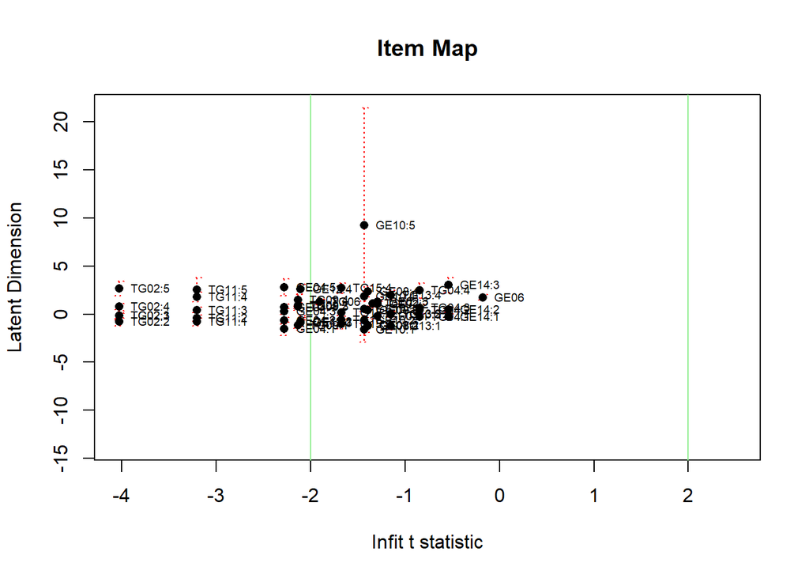

```r
plotPWmap(pcm, itemCI=list(gamma=0.95,col="red",lty="dotted"))
```

Insgesamt muss an dieser Stelle aber gesagt werden, dass diese z-Statistiken herangezogen werden sollten, wenn die Items nach den normalen Outfit/Infit Kritererien nicht fitten. Insgesamt kann also dennoch davon ausgegangen werden, dass unser PCM Modell die Daten gut erklären kann. Dass das Modell auf manche der Items overfitted, muss bei entsprechenden Reliabilitätsanalysen bedacht werden.

Genauso können wir uns übrigens anschauen, welche Personen nicht durch das Model erklärbar sind.

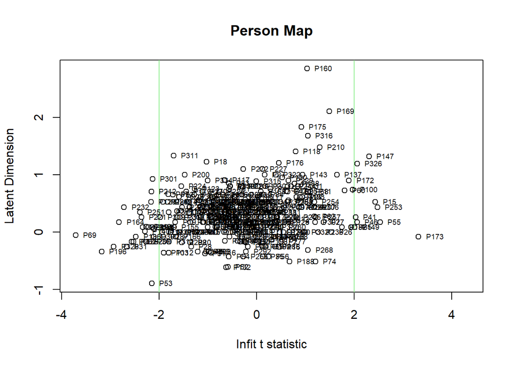

```r
plotPWmap(pcm, pmap=TRUE, imap = FALSE, itemCI=list(gamma=0.95,col="red",lty="dotted"))
```

Das Model kann den Großteil des Verhaltens der Befragten erklären. Wir könnten nun die anderen Befragten genauer anschauen. Wir könnten zum Beispiel auf ein auffälliges Antwortverhalten untersuchen, welches auf schnelles durchklicken hindeutet. An dieser Stelle wollen wir uns jedoch erst einmal weiter dem Modelfit widmen.

Während wir gerade den fit einzelner Items untersucht haben, können wir uns auch mittels den Informationskriterien AIC und BIC allgemeine Aussagen über den Informationsgehalt unseres Models anschauen. An dieser Stelle sei angemerkt, dass nach (Embretson & Reise, p.233f.) der allgemeine model-data fit eine untergeordnete Rolle spielt, daher wollen wir uns ihm nur kurz widmen.

AIC (Akaike information criterion) und BIC (Bayesian information criterion) geben an, wie viele Informationen durch das Model verloren gehen. Je geringer der Wert, desto besser. Dazu muss gesagt sein, dass der Wert abhängig von den Daten und Items ist. Das heißt, der Wert bringt uns nur etwas, wenn wir ihn mit einem anderen Model vergleichen.

```r
# AIC und BIC Modell berechnen
modelfit_pcm <- IC(ppar_pcm)
modelfit_pcm
```

```
##
## Information Criteria:
##                         value npar       AIC       BIC      cAIC
## joint log-lik       -5264.820  142 10813.640 11354.822 11496.822
## marginal log-lik    -5646.716   52 11397.431 11595.611 11647.611
## conditional log-lik -4657.592   52  9419.184  9617.364  9669.364
```

```r
# pcm_data_testlet <- question_scores %>%
#   select(ends_with("Score_Testlet")) %>%
#   filter(rowSums(!is.na(.)) > 1)
#
# pcm_data_formula <- question_scores %>%
#   select(ends_with("Score_Formula")) %>%
#   filter(rowSums(!is.na(.)) > 1)
#
# pcm_testlet <- PCM(pcm_data_testlet)
# ppar_pcm_testlet <- person.parameter(pcm_testlet)
# itemfit_pcm_testlet <- itemfit(ppar_pcm_testlet)
# print(itemfit_pcm)
#
# modelfit_pcm_testlet <- IC(ppar_pcm_testlet)
# print(modelfit_pcm_testlet)
# pcm_formula <- PCM(pcm_data_formula)
#
# pcm_formula <- PCM(pcm_data_formula)
```

Insgesamt können wir feststellen, dass unser Model angemessen gut fittet. Geben wir als nächstes in die Analyse was unser Model über die Daten sagt und wo anscheinend Probleme in den Items sind.

### Itemanalyse

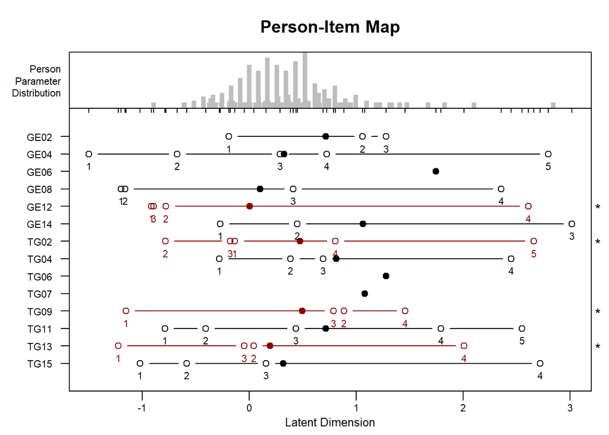

```r
plotPImap(pcm, item.subset = c('GE02','GE04','GE06','GE08','GE12','GE14','TG02','TG04','TG06','TG07','TG09','TG11','TG13','TG15'), warn.ord.colour="darkred", irug = TRUE)
```

Die Items GE06, TG06 und TG07 sehen hier anders aus, weil diese Single Choice Aufgaben sind und dementsprechend nur 1 oder 0 sein können. Sie haben also nur eine Schwelle, weshalb keine Intervallskala wie bei den anderen Items eingezeichnet werden kann.

Allgemein betrachtet können wir erst einmal feststellen, dass ein Großteil der Items die ganze Range der Befragten abdecken. Dabei ist zu beachten, dass jeweils der erste Punkt mit einer 1 bedeutet, dass hier die Wahrscheinlichkeit einen Punkt zu erreichen bei $50\%$ liegt. Das heißt, Personen die links vom ersten Punkt und rechts von der Maximalpunktzahl liegen, werden trotzdem gemessen.

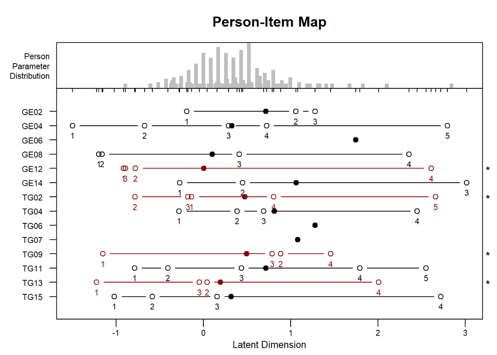

```r
plotPImap(pcm, item.subset = c('GE02','GE04','GE06','GE08','GE12','GE14','TG02','TG04','TG06','TG07','TG09','TG11','TG13','TG15'), warn.ord.colour="darkred", irug = TRUE)
```

Auffällig ist, dass es einige Items gibt, bei denen das Erreichen der letzten Schwelle so schwer ist, dass kaum jemand der Befragten dieses Fähigkeitsnivau erreicht hat (im pre-test wohlgemerkt). Dies ist der Fall bei den Items GE04, GE14 und (etwas weniger drastisch) GE12, TG02, TG11 und TG15. Diese kann man sich einmal vormerken, eventuell ist hier eine Antwortoption “zu überzeugend” formuliert oder kann zu leicht als richtig interpretiert werden. Eventuell haben die Befragten hier aber auch nur sehr stark ausgeprägte Präkonzepte. Hier ist es auf jeden Fall relevant zu schauen, wie die Fragen im Posttest beantwortet werden.

Andersherum können wir auch betrachten, welche Items eine zu leichte erste Schwelle haben. Hier sei zuerst GE14 angeführt. Hier hatte kein Schüler in der Befragung überhaupt 0 Punkte, weswegen die Skala sowieso schon um 1 nach rechts verschoben ist. Ansonsten sind noch GE04, GE08, GE12, TG09, TG13 und TG15 besonders auffällig.

| Frage | Anmerkung |
| --- | --- |
| GE04 | **Erste Schwelle unter Fähigkeitsnivau der Befragten.** Letzte Schwelle weit über Fähigkeitsnivau der Befragten. |
| GE08 | **Erste Schwelle leicht unter Fähigkeitsnivau der Befragten.** |
| GE12 | **Erste Schwelle leicht unter Fähigkeitsnivau der Befragten.** Letzte Schwelle über Fähigkeitsnivau der Befragten. |
| GE14 | **Alle Befragten hatten mindestens einen Punkt.** Letzte Schwelle über Fähigkeitsnivau der Befragten. |
| TG02 | Letzte Schwelle über Fähigkeitsnivau der Befragten. |
| TG09 | **Erste Schwelle leicht unter Fähigkeitsnivau der Befragten.** |
| TG11 | Letzte Schwelle über Fähigkeitsnivau der Befragten. |
| TG13 | **Erste Schwelle leicht unter Fähigkeitsnivau der Befragten.** |
| TG15 | **Erste Schwelle leicht unter Fähigkeitsnivau der Befragten.** Letzte Schwelle über Fähigkeitsnivau der Befragten. |

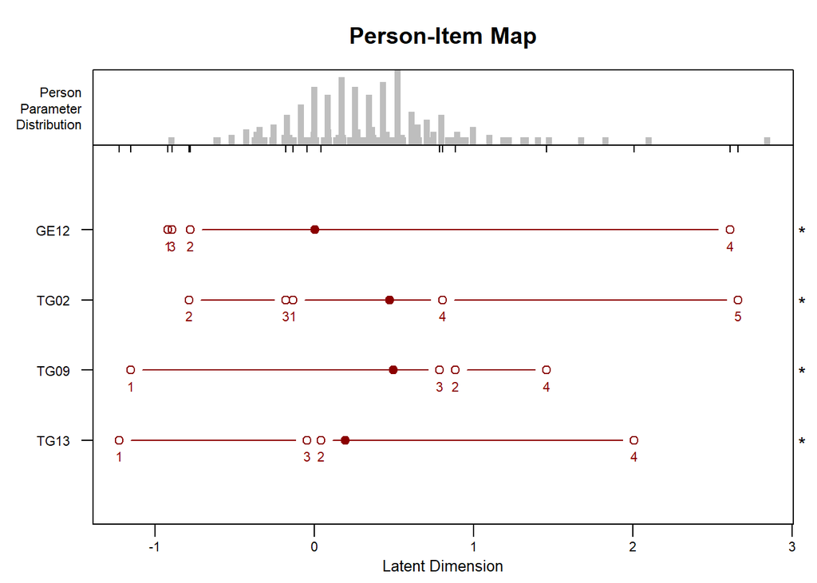

```r
plotPImap(pcm, item.subset = c("GE12", "TG02", "TG09", "TG13"), warn.ord.colour="darkred", irug = TRUE)
```

| Frage | Anmerkung |
| --- | --- |
| GE04 | Erste Schwelle weit unter Fähigkeitsnivau der Befragten. Letzte Schwelle weit über Fähigkeitsnivau der Befragten. |
| GE08 | Erste Schwelle leicht unter Fähigkeitsnivau der Befragten. |
| GE12 | **Schwelle 2 und 3 sind knapp vertauscht. Schwellen 1,2,3 sehr nah beianander.** |
| GE14 | Alle Befragten hatten mindestens einen Punkt. Letzte Schwelle weit über Fähigkeitsnivau der Befragten. |
| TG02 | **Schwelle 1, 2 und 3 sind vertauscht.** |
| TG09 | Erste Schwelle leicht unter Fähigkeitsnivau der Befragten. **Schwelle 2 und 3 sind knapp vertauscht.** |
| TG13 | Erste Schwelle leicht unter Fähigkeitsnivau der Befragten. **Schwelle 2 und 3 sind knapp vertauscht.** |
| TG15 | Erste Schwelle leicht unter Fähigkeitsnivau der Befragten. |

An dieser Stelle sei nochmal darauf hingewiesen, dass für die meisten Schwellen diese nur sehr knapp vertauscht sind. Es sollten auf jeden Fall auch die Postmessungen später untersucht und einbezogen werden werden.

| Frage | Anmerkung |
| --- | --- |
| GE04 | Erste Schwelle weit unter Fähigkeitsnivau der Befragten. Letzte Schwelle weit über Fähigkeitsnivau der Befragten. |
| GE08 | Erste Schwelle leicht unter Fähigkeitsnivau der Befragten. |
| GE12 | **Schwelle 2 und 3 sind knapp vertauscht. Schwellen 1,2,3 sehr nah beianander.** |
| GE14 | Alle Befragten hatten mindestens einen Punkt. Letzte Schwelle weit über Fähigkeitsnivau der Befragten. |
| TG02 | **Schwelle 1, 2 und 3 sind vertauscht.** |
| TG09 | Erste Schwelle leicht unter Fähigkeitsnivau der Befragten. **Schwelle 2 und 3 sind knapp vertauscht.** |
| TG13 | Erste Schwelle leicht unter Fähigkeitsnivau der Befragten. **Schwelle 2 und 3 sind knapp vertauscht.** |
| TG15 | Erste Schwelle leicht unter Fähigkeitsnivau der Befragten. |

Zuletzt wollen wir uns noch einmal das Item GE10 anschauen. Diese wurde bisher in den Plots nicht miteinbezogen.

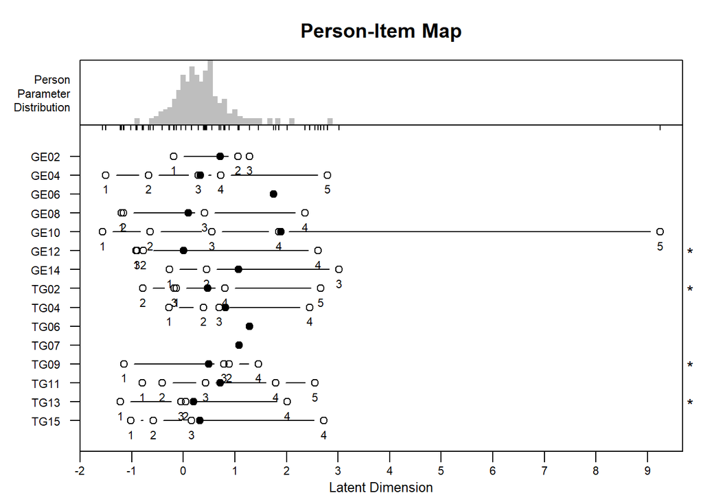

```r
plotPImap(pcm)
```

Anscheinend ist es extrem schwer bei diesem Item 5 Punkte zu erreichen. Auch die Schwelle für einen Punkt ist zu niedrig. Dieses Item muss wahrscheinlich überarbeitet werden.

| Frage | Anmerkung |
| --- | --- |
| GE04 | Erste Schwelle weit unter Fähigkeitsnivau der Befragten. Letzte Schwelle weit über Fähigkeitsnivau der Befragten. |
| GE08 | Erste Schwelle leicht unter Fähigkeitsnivau der Befragten. |
| GE10 | Erste Schwelle weit unter Fähigkeitsnivau der Befragten. **Letzte Schwelle extrem weit über Fähigkeitsnivau der Befragten.** |
| GE12 | **Schwelle 2 und 3 sind knapp vertauscht. Schwellen 1,2,3 sehr nah beianander.** |
| GE14 | Alle Befragten hatten mindestens einen Punkt. Letzte Schwelle weit über Fähigkeitsnivau der Befragten. |
| TG02 | **Schwelle 1, 2 und 3 sind vertauscht.** |
| TG09 | Erste Schwelle leicht unter Fähigkeitsnivau der Befragten. **Schwelle 2 und 3 sind knapp vertauscht.** |
| TG13 | Erste Schwelle leicht unter Fähigkeitsnivau der Befragten. **Schwelle 2 und 3 sind knapp vertauscht.** |
| TG15 | Erste Schwelle leicht unter Fähigkeitsnivau der Befragten. |

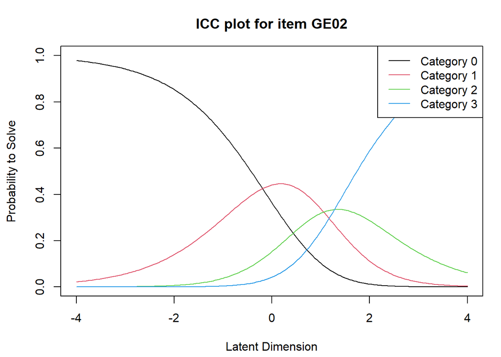

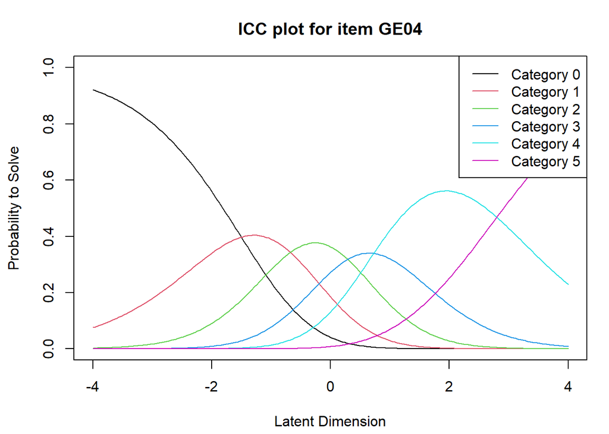

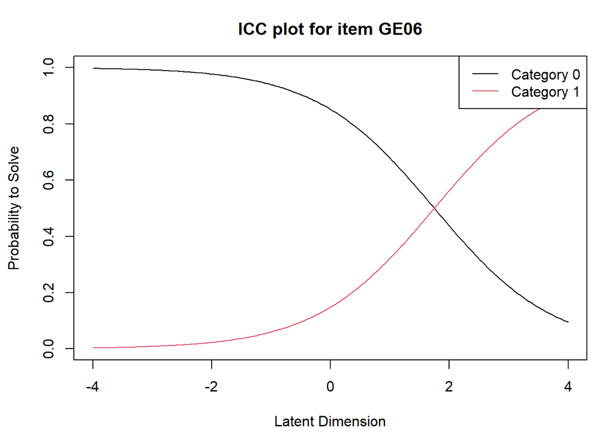

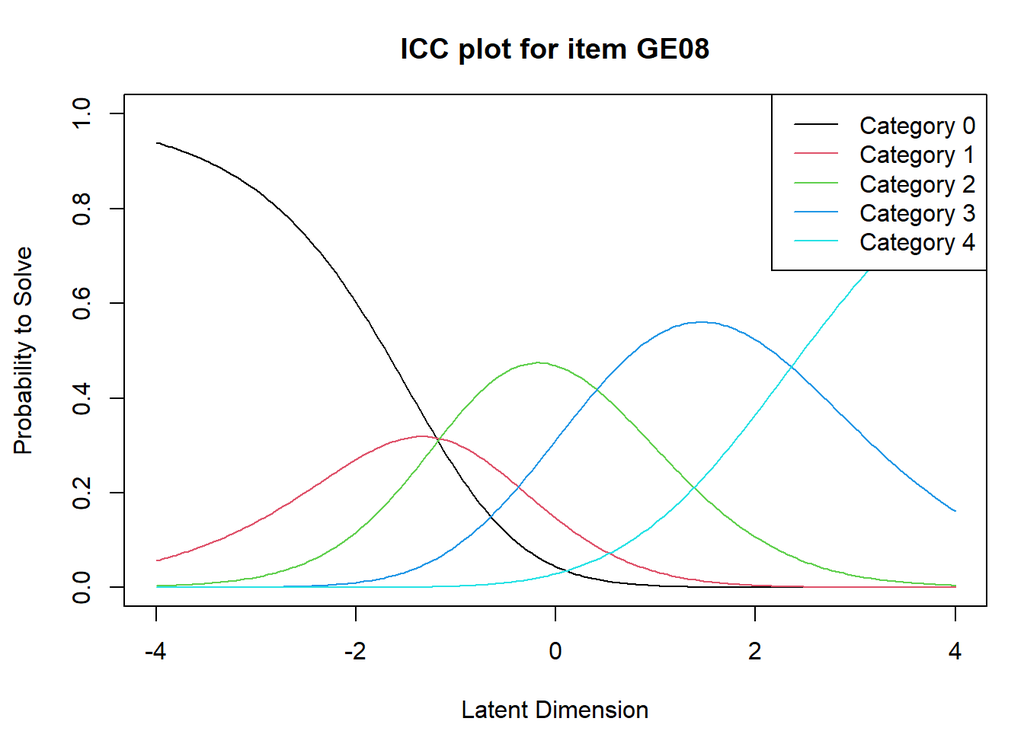

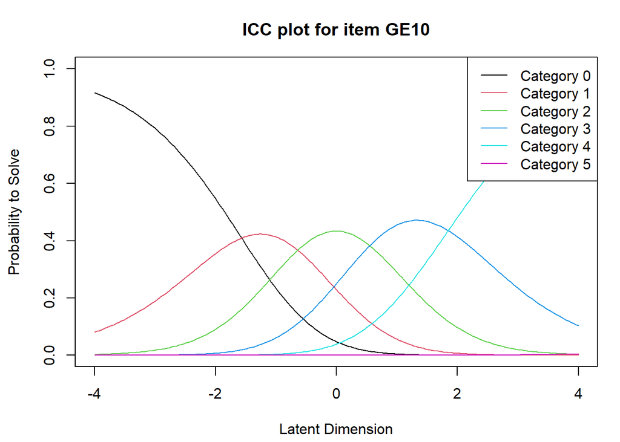

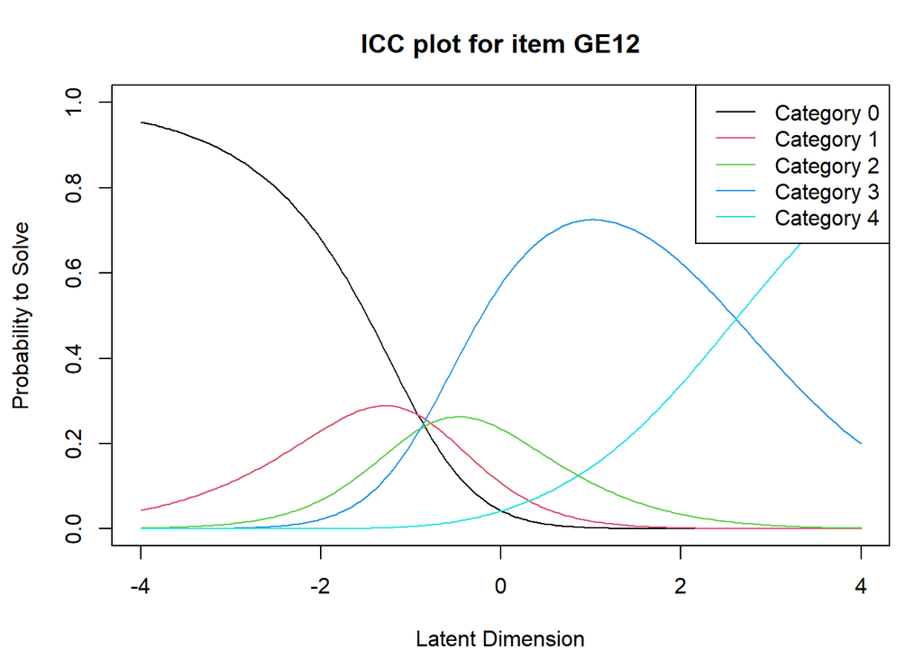

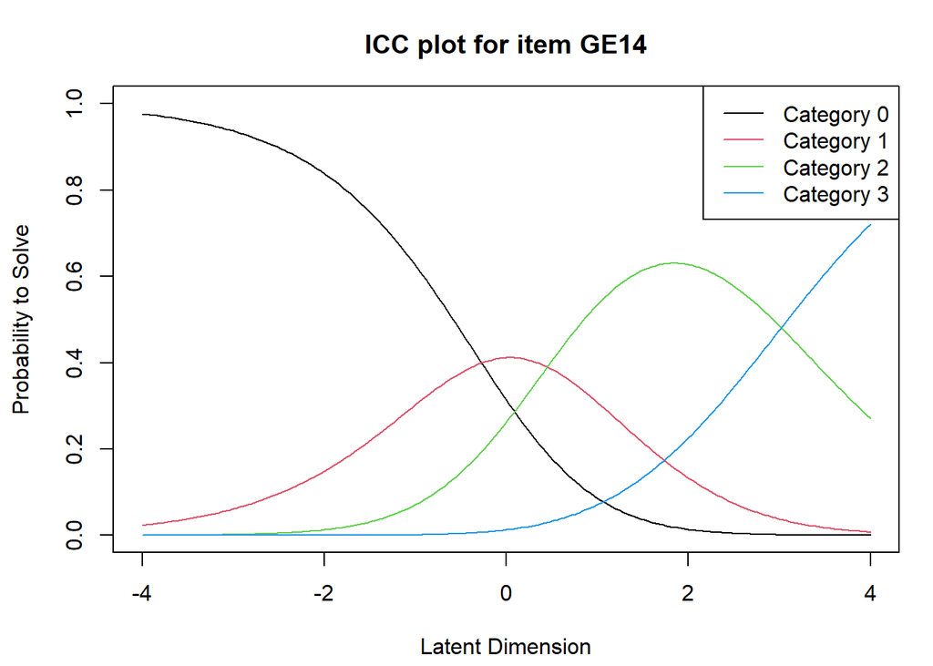

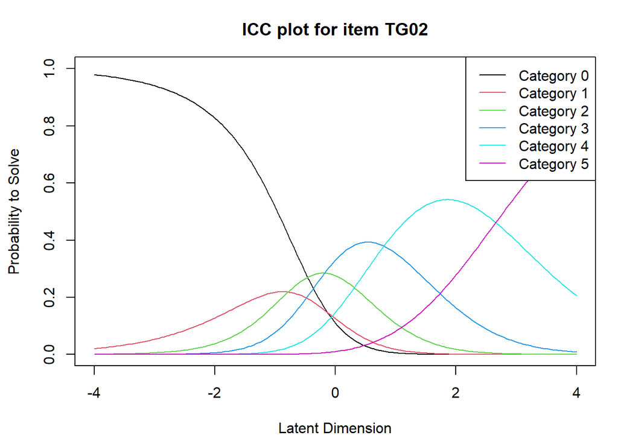

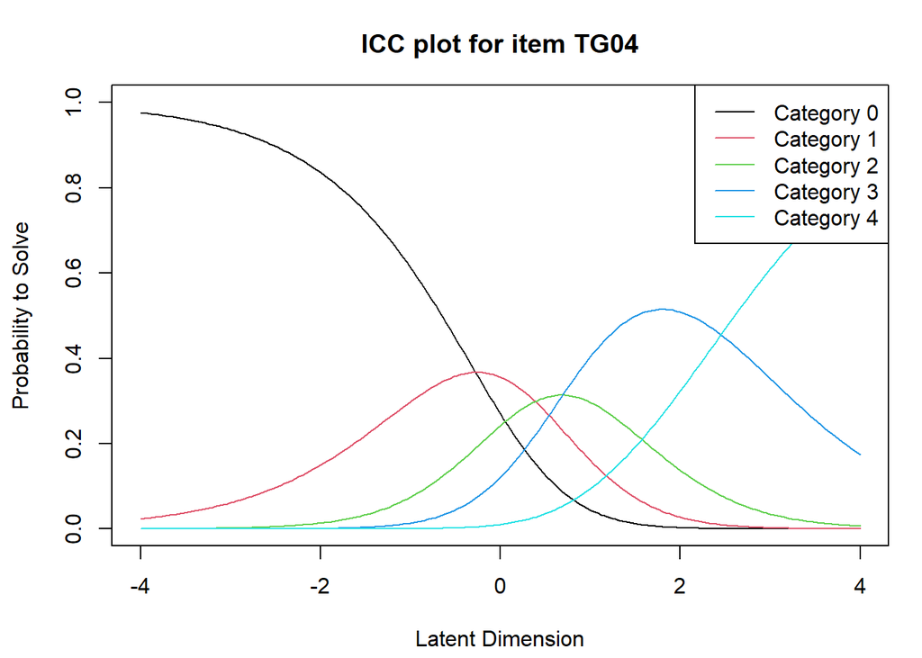

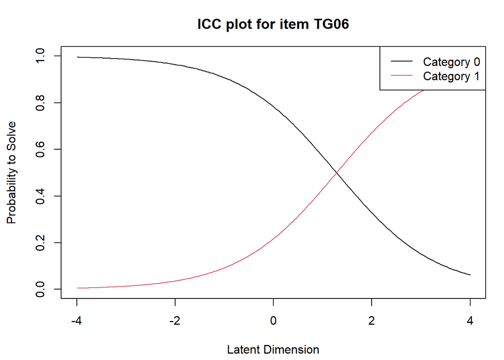

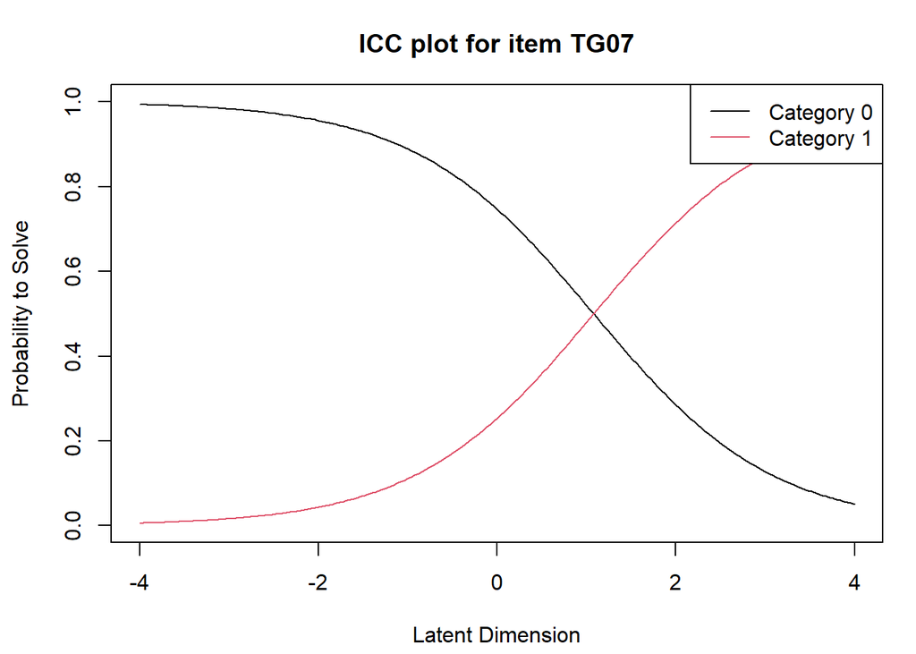

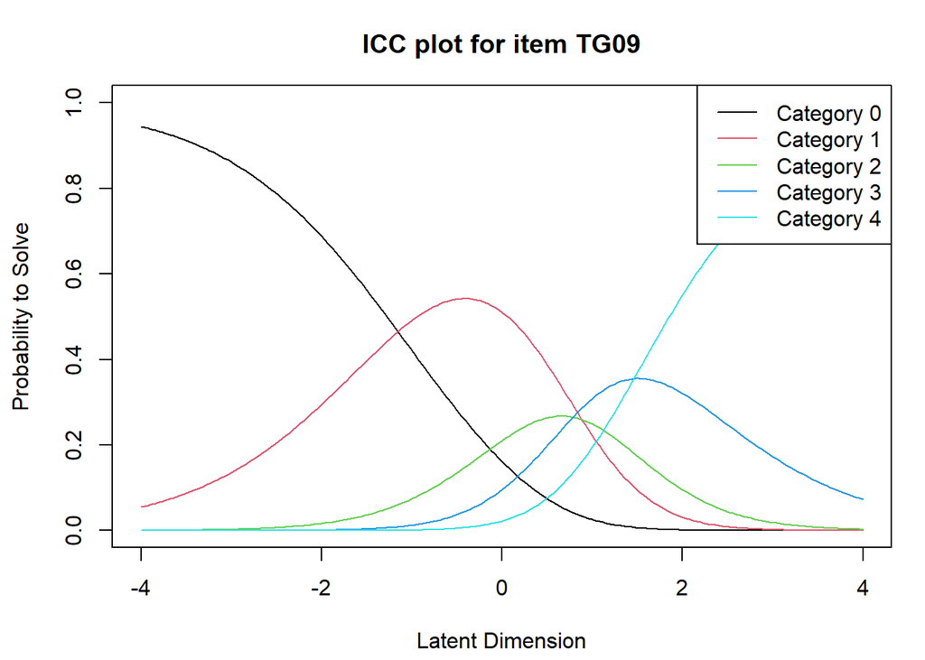

[3 more figures not shown]

```r
plotICC(pcm, mplot = FALSE, legpos = "topright", ask = FALSE)
```

Hier sind noch einmal die Item-Characteristic-Curves dargestellt. Wir können hier auch nochmal grafisch die problematischen Schwellen der Items sehen. Bei allen problematischen Items ist eine der Linien (Zum Beispiel grün für 2 Punkte bei Item TG09) immer unter den anderen Linien. Das heißt, es gibt keinen Moment, in dem es am wahrscheinlichsten ist zwei Punkte erreicht zu haben, aber nicht drei Punkte. Wir sehen aber, dass bei den meisten problematischen Items die Linien fast einen Schnittpunkt bilden, der Unterschieden also fast nicht existent ist.

```r
#splitvec <- sample(1:2, 314, replace = TRUE)

# lrtest_pcm <- LRtest(pcm, splitcr = splitcr)
# plotGOF(lrtest_pcm)
```

### Reliabilität

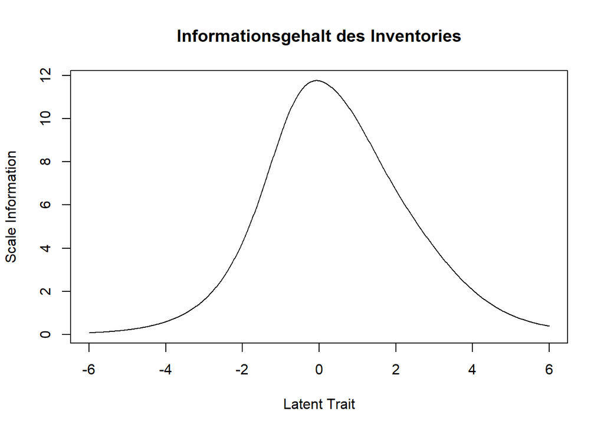

```r
plotINFO(pcm, type = "test", mainT="Informationsgehalt des Inventories",legpos = "right")
```

Dieser Plot zeigt uns, wie genau unsere Skala abhängig von den Fähigkeiten der Befragten misst. Wir sehen, dass unsere Skala am besten für Personen mit einer mittleren Fähigkeitsausprägnung misst, wohingegen Messungen bei besonders starken oder schwachten Befragten mit viel Unsicherheit verbunden sind.

- über KR-20, Cronbachs Alpha oder Rasch Seperation Reliability (https://www.rasch.org/mra/mra-12-08.htm)

Als letzte Metrik für den Gesamtscore schauen wir uns die Reliabilität des Fragebogens an.

Korrelationsmatrix

Schauen wir uns erst einmal die Korrelationen der Fragen untereinander an. Innerhalb einer Anwendung (Gesichtserkennung oder Textgenerierung) sollten die Fragen wenig miteinander korrelieren. Dies würde dafür sprechen, dass die Fragen unabhängig voneinander beantwortet werden können. Ausnahmen bilden hier die Fragen zu den Konzepten *Programmierung* und *Evaluation*, weil für diese bereits im Vorfeld eine Abhängigkeit zu anderen Konzepten erwartet wurde.

Über beide Anwendungen hinweg ist nicht genau klar, wie Fragen zum gleichen Konzept korrelieren sollten. Einerseits fragen sie das gleiche Konzept ab, wodurch ein Zusammenhang erwartbar ist. Andererseits ist auch erwartbar, dass aufgrund der unterschiedlichen mentalen Modelle zu den Anwendungen, die Konzepte ganz anders wahrgenommen werden.

Wir betrachten zuerst die Korrelationsmatrizen für die einzelnen Anwendungen. Wir berechnen die Spearman-Korrelation.

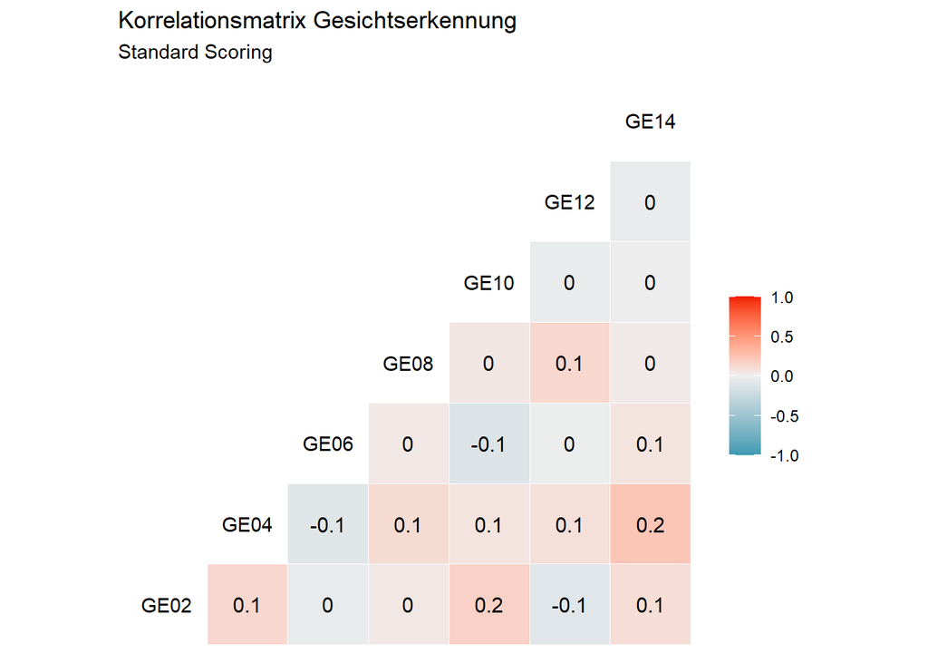

Schauen wir uns nun analog die Abhängigkeiten bei der Textgenerierung an.

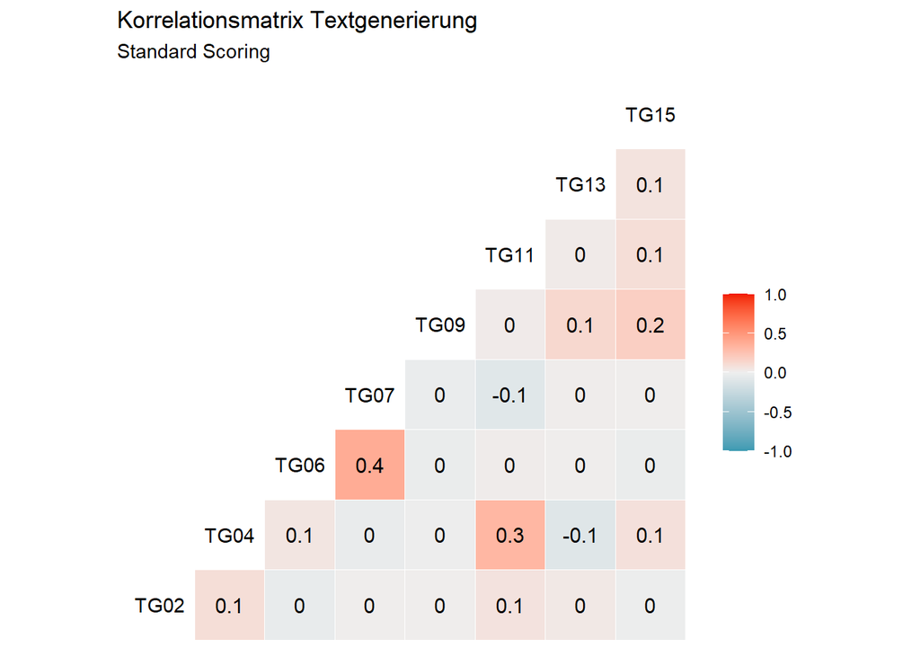

Schauen wir uns nun noch die Korrelationen über alle Fragen an.

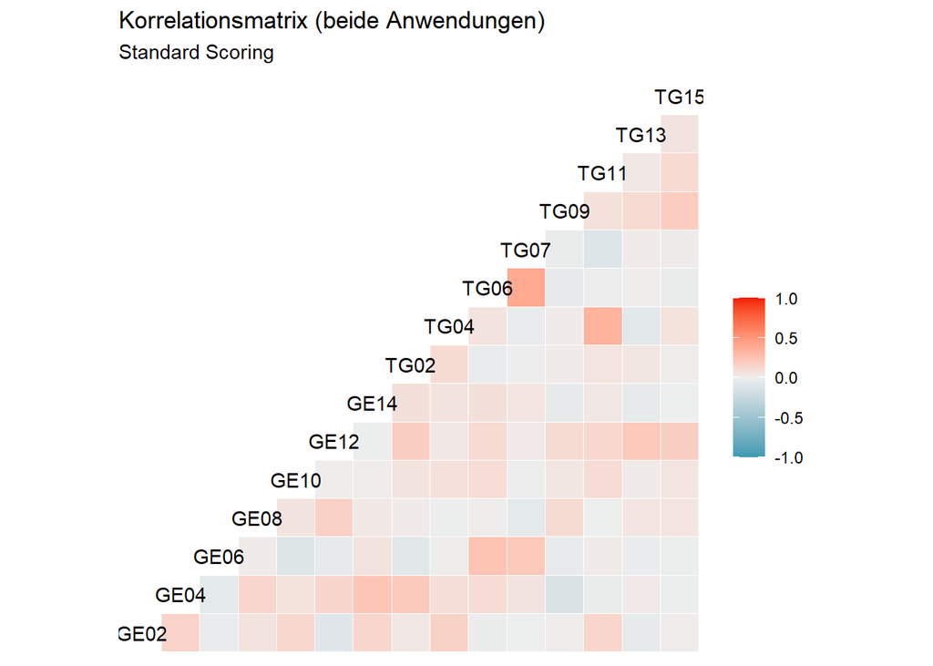

Insgesamt existieren weitere “erhöhte” Korrelationen zwischen Fragen, die hier nicht weiter ausgeführt werden. Es ist noch nicht klar, welche Einfluss diese Korrelationen auf die Testreliablität haben. Schauen wir uns dazu Cronbachs’ Alpha an.

## Cronbachs’ Alpha

[1] “**Alpha(Standard Scoring):** 0.46”

Cronbachs’ Alpha und Guttman’s Lambda, wenn Item gedropt wird.

|  | raw_alpha | G6(smc) |
| --- | --- | --- |
| GE02 | 0.44 | 0.48 |
| GE04 | 0.42 | 0.45 |
| GE06- | 0.46 | 0.49 |
| GE08 | 0.45 | 0.48 |
| GE10 | 0.44 | 0.48 |
| GE12 | 0.42 | 0.44 |
| GE14 | 0.45 | 0.48 |
| TG02 | 0.43 | 0.47 |
| TG04 | 0.43 | 0.46 |
| TG06 | 0.46 | 0.45 |
| TG07 | 0.47 | 0.47 |
| TG09 | 0.46 | 0.49 |
| TG11 | 0.42 | 0.46 |
| TG13 | 0.46 | 0.49 |
| TG15 | 0.44 | 0.47 |

## GRM

Wir können auch andere IRT Modelle verwenden. Probieren wir doch mal das Graded Response Model aus.

```r
library(ltm)
grm_data <- data_score_standard %>%
  mutate(across(c(GE06, TG06, TG07), ~ifelse(.==1,2,ifelse(.==0,1,.))))

grm <- grm(grm_data)
summary(grm)
```

```
##
## Call:
## grm(data = grm_data)
##
## Model Summary:
##    log.Lik      AIC      BIC
##  -5471.425 11078.85 11338.62
##
## Coefficients:
## $GE02
##          value
## Extrmt1 -2.058
## Extrmt2  2.156
## Extrmt3  5.544
## Dscrmn   0.459
##
## $GE04
##           value
## Extrmt1 -13.878
## Extrmt2  -5.357
## Extrmt3  -0.228
## Extrmt4   4.092
## Extrmt5  12.095
## Dscrmn    0.321
##
## $GE06
##           value
## Extrmt1 -22.274
## Dscrmn   -0.067
##
## $GE08
##           value
## Extrmt1 -20.453
## Extrmt2  -9.467
## Extrmt3   1.607
## Extrmt4  14.929
## Dscrmn    0.195
##
## $GE10
##           value
```

[output cut: 76 more lines]

```
## Extrmt1 -10.239
## Extrmt2  -3.730
## Extrmt3   0.439
## Extrmt4   6.545
## Dscrmn    0.407
##
##
## Integration:
## method: Gauss-Hermite
## quadrature points: 21
##
## Optimization:
## Convergence: 0
## max(|grad|): 0.039
## quasi-Newton: BFGS
```